# Writeup

Zhengqi Tian

10/20/2021

# Introduction

In this post, we are going to talk about the distribution fo order statistic. The sample here is focusing analyzing the continuous standard normal distribution with size equals 200. We trying to ansser a series of question related to the variation of median and a range of quantile. We will use density function, the probability function and the quantile function for specific questions.

**Questions1:** Begin with the median from a sample of N = 200 from the standard normal distribution. Write an R function that is the density function for the median in this sample. Note that the 100th order statistic is approximately the median, and use the order statistic formula discussed in class. Generate a plot of the function.

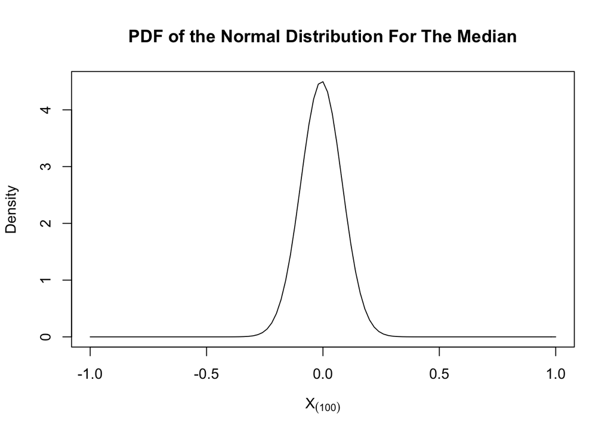

```r
dorder <- function(x){
    k<-100
    n<-200
    k*
  choose(n,k)*
  (pnorm(x))^(k-1)*
  (1-pnorm(x))^(n-k)*
  dnorm(x)
}

#plotting the PDF
curve(dorder(x), -1, 1,main = "PDF of the Normal Distribution For The Median", xlab = parse(text="X[(100)]"),ylab = "Density")
```

**Questions2:** Write an R function that is the probability function for the median in this sample. Use the order statistic formula discussed in class. Generate a plot of the function.

To answer the question, we are looking to to find probability distribution and CDF plot for the standard normal distribution. As a sample of N is 200, the median here is 100. As we are looking for CDF, we will use pbinom() function and pnorm() here. From the graph, we can find that the median is close to 0. The rane is from -0.25 to 0.25 The result is close to PDF result.

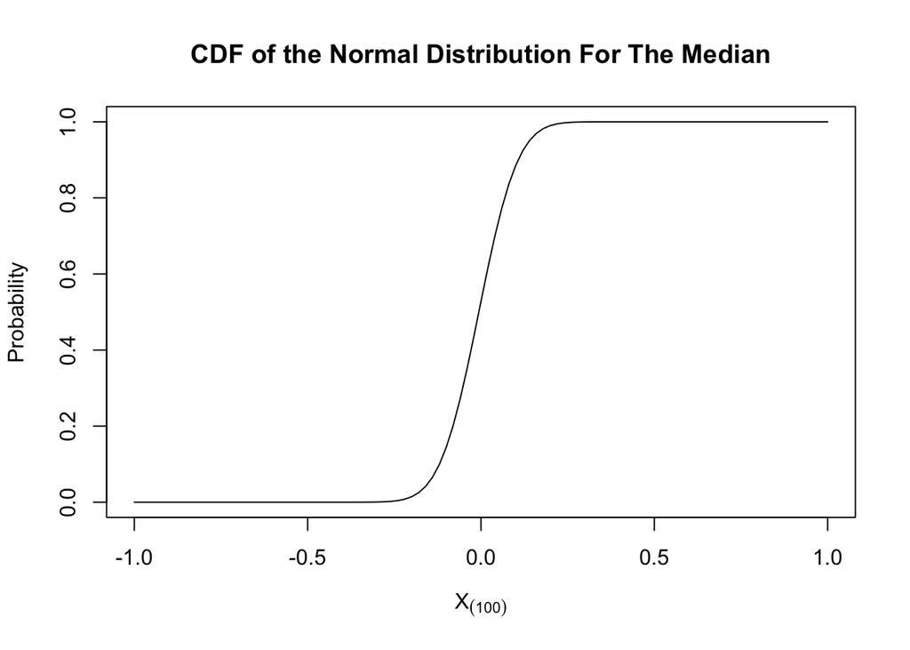

```r
porder <- function(x){
    k<-100
    n<-200
  pbinom(k-1, n, pnorm(x), lower.tail = F)
}
curve(porder(x), -1, 1, main = "CDF of the Normal Distribution For The Median", xlab=parse(text="X[(100)]"),ylab = "Probability")
```

**Questions3:** Write an R function that is the quantile function for the median in this sample. (You have several options for how to write this function.) Generate a plot of the function.

To answer the question, we are trying to find the inverse of the probability function. Uniroot is a good expression to find the outcome. From the graph, we can find the the possible quantile result is from -0.2 to 0.2. The result is close to the find we have from CDF. We can have a similar result that the median is close to 0

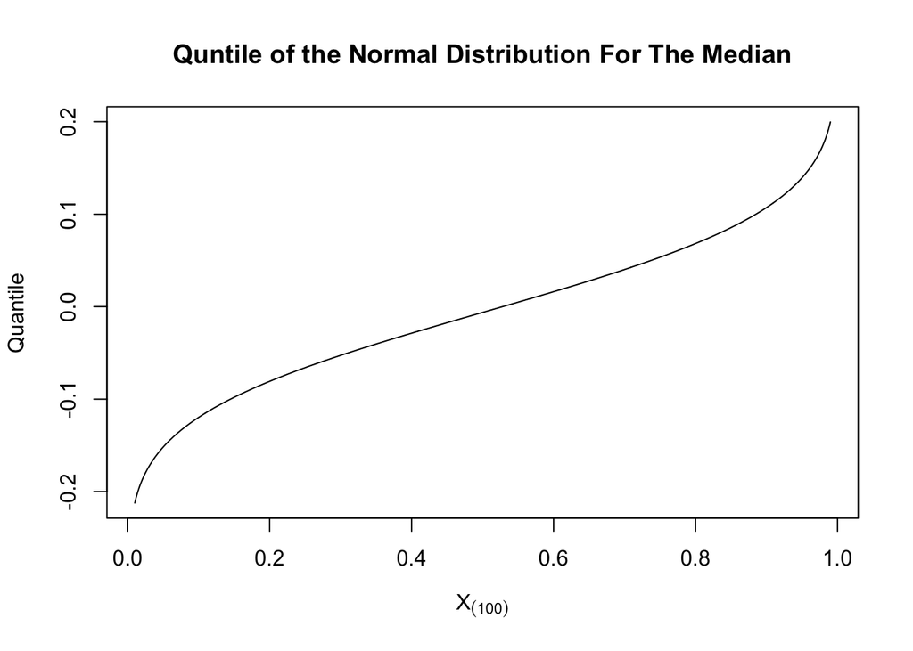

```r
ps <- seq(0.01, 0.99, by = 0.001)
qs <- NA

qorder <- function(p){
  k <- 100
  n <- 200
  for(i in seq_along(p)){
    qs[i] <- uniroot(function(x) porder(x)-p[i], c(-10,10))$root
  }
  qs
}


plot(ps,qorder(ps),type = "l", main = "Quntile of the Normal Distribution For The Median", xlab = parse(text="X[(100)]"), ylab = "Quantile")
```

**Questions4:** Simulate the sampling distribution for the median. Create a plot of the empirical CDF (ECDF). Overlay the plot of the ECDF with a plot of the CDF. Here, we are trying to compare the simulated probability with theoretical probability. To simulate the the sampling distribution for the median, we set 10000 running times for the median. rnorm() is a good function to have the reustlt.Then we will use ecdf to have the CDF plot. From the plot, we are able to have a very close result. the simulation sample CDF is close to the estimated CDF. The median is close to 0. and the range is crom -0.2 to 0.2.

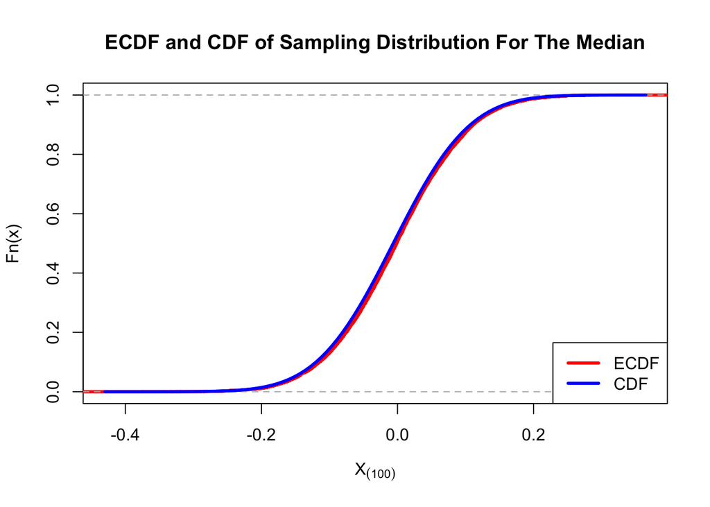

```r
simulation.median<- NA

for(i in 1: 10000){
  simulation.median[i] <- median(rnorm(200))
}

ecdf <- ecdf(simulation.median)

plot(ecdf, do.points = F, col = "Red", lwd = 3, main = "ECDF and CDF of Sampling Distribution For The Median",xlab = parse(text="X[(100)]"))
curve(porder(x), add = T, col = "blue", lwd = 3)
legend(
  "bottomright",
  c("ECDF", "CDF"),
  lwd = 3,
  col = c("Red", "blue")
)
```

**Questions5:**Using the simulated sampling distribution from the previous question, create a histogram (on the density scale). Overlay the histogram with a plot of the density function.

Here, we are trying to compare the simulation density with theoretical density. We will use the simulation result from the previous questions. Hist() function helps us have the histogram graph. Here, we set the break as 100 for more detail. From the plot, The pdf has same tendency as the histgram has. The higest poist are close here. We are able to have a very close result. The median is close to 0 and the range is from -0.2 to 0.2.

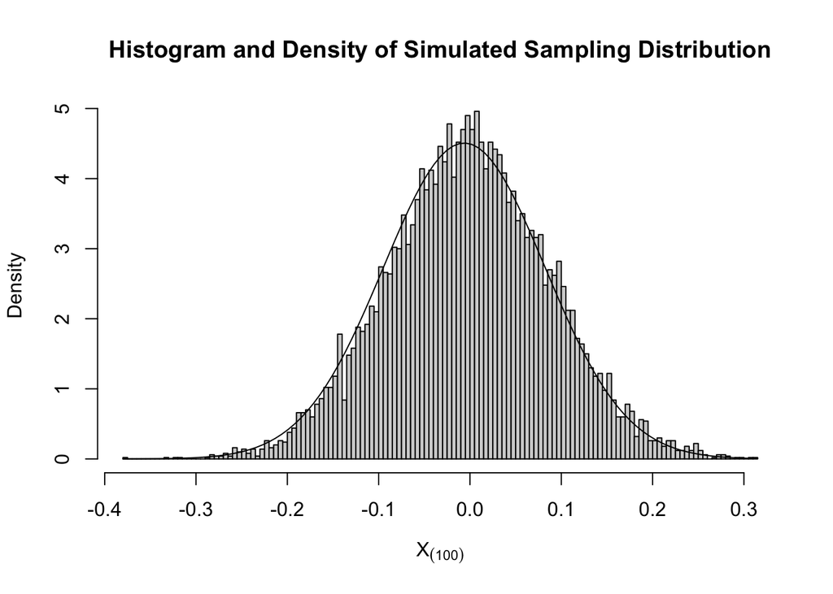

```r
hist(simulation.median,freq = F,main= "Histogram and Density of Simulated Sampling Distribution",xlab = parse(text="X[(100)]"),breaks=100)
curve(dorder(x), add = T)
```

**Questions5:** One very common way to compare a random sample to a theoretical candidate distribution is the QQ plot. It is created by ploting quantiles of the theoretical distribution on the x-axis and empirical quantiles from the sample on the y-axis.For the assigment, generate a QQ plot for the simulated data of the median relative to the known sampling distribution of the median.Does the simulated data agree with the theoretical sampling distribution?

To find the result, we need compare the simulation median and the theoretic order. We point have a large quantile sets here to improve the accuracy. From the result, we find that the simulated quantile result is same with the theoretical quantile result. the point is close to y=x. Thus, we could say that the theoretical quantile is same as the simulated quantile.

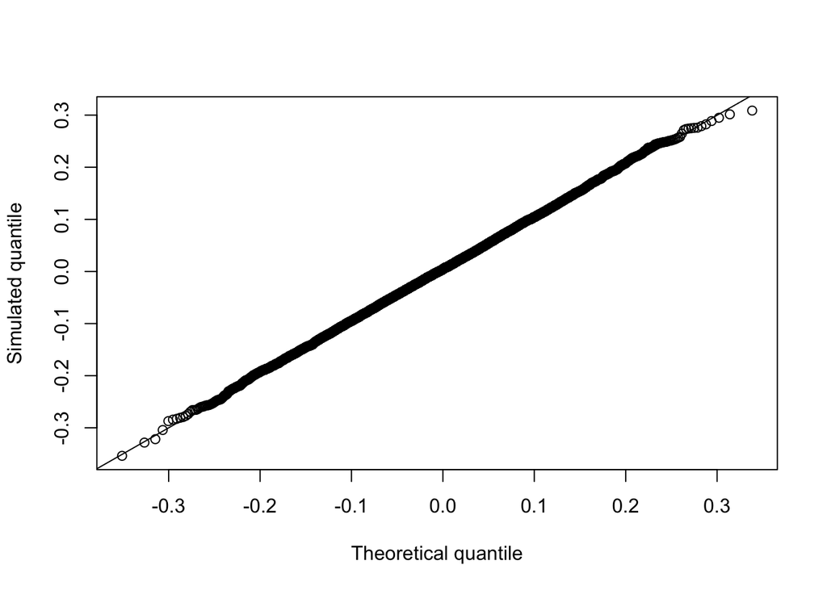

```r
simulated_sample <- simulation.median
q_candidate <- qorder

p <- ppoints(10000)

x <- qorder(p)
y <- quantile(simulated_sample, probs = p)

plot(x,y,xlab = "Theoretical quantile", ylab = "Simulated quantile")
abline(0,1)
```

**Questions6:** Modify the dorder, porder, and qorder functions so that the functions take a new parameter k (for the kt**h order statistic) so that the functions will work for any order statistic and not just the median.

Different from the previous function, which has one x, we put x and k as modification.

```r
# dorder
dorder <- function(x,k){
  n=200
  k*
  choose(n,k)*
  (pnorm(x))^(k-1)*
  (1-pnorm(x))^(n-k)*
  dnorm(x)
}

# porder
porder <- function(x,k){
  n=200
  pbinom(k-1, n, pnorm(x), lower.tail = F)
}

# qorder
ps <- seq(0.01, 0.99, by = 0.001)
qs <- NA

qorder <- function(p,k){
  n <- 200
  for(i in seq_along(p)){
    qs[i] <- uniroot(function(x,y) porder(x,k)-p[i], c(-10,10))$root
  }
  qs
}
```

**Questions7:** Generate the QQ plot for simulated data from the sampling distribution of the sample max and the theoretical largest order statistic distribution.

The general idea of the QQ plot for sample max is similar with QQ plot for sample mean. To find the simulated max, we will use max() function. For the theoretical max, we look for 200 for k. From the result, we find that the simulated quantile result is same with the theoretical quantile result. the point is close to y=x. Thus, we could say that the theoretical quantile is same as the simulated quantile.

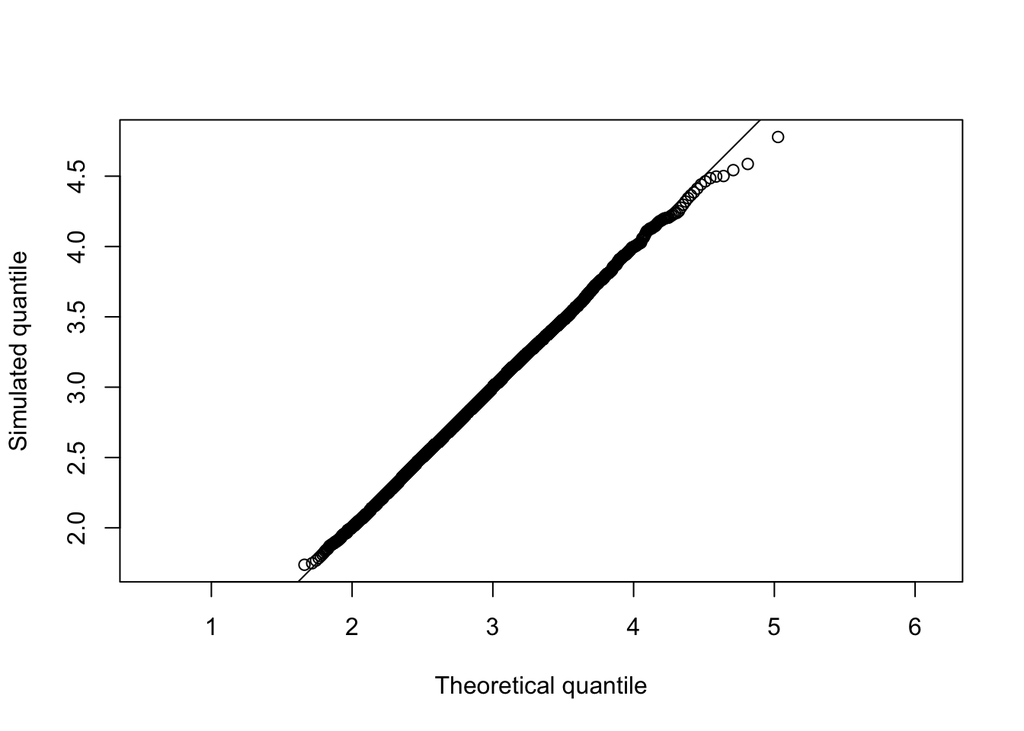

```r
simulation.max <- NA   # distribution of medians of the M times of simulation

for(i in 1:10000){
  simulation.max[i] <- max(rnorm(200))
}

simulated_sample <- simulation.max
q_candidate <- qorder

x <- qorder(p,k=200)
y <- quantile(simulated_sample, probs = p)

plot(x, y, asp = 1, xlab = "Theoretical quantile", ylab = "Simulated quantile")
abline(0, 1)
```

**Questions8:** Modify the dorder, porder, and qorder functions so that the functions take new parameters dist and … so that the functions will work for any continuous distribution that has d and p functions defined in R.

Different from the previous function, which has x and k as input, we put more inputs varies here.

```r
`%|%` <- function(a, b) paste0(a,b)

dorder <- function(x, k, dist = norm, ...) {
  pf <- get("p" %|% dist)
  df <- get("d" %|% dist)
  n <- 200
  k * choose(n, k) *
  (pf(x, ...)) ^ (k - 1) *
  (1 - pf(x, ...)) ^ (n - k) *
  df(x, ...)
}

porder <- function(x, k, dist = norm, ...){
  pf <- get("p" %|% dist)

  n <- 200
  pbinom(k-1, n, pf(x,...), lower.tail = FALSE)
}

qorder <- function(p, k){
  pf <- get("p" %|% dist)

  n <- 200
  for(i in seq_along(p)){
    med_dis[i] <- uniroot(function(x, y) porder(x, k, ...)-p[i], c(-10,10))$root
  }
  med_dis
}
```

**Questions7:** Use the newly modified functions to plot the probability and density functions for the sample min (N = 200).

Here, we try to find the density and dorder() for sample min. Sample min,k,here is 1. From the plot, we find the min is between -2 and -4

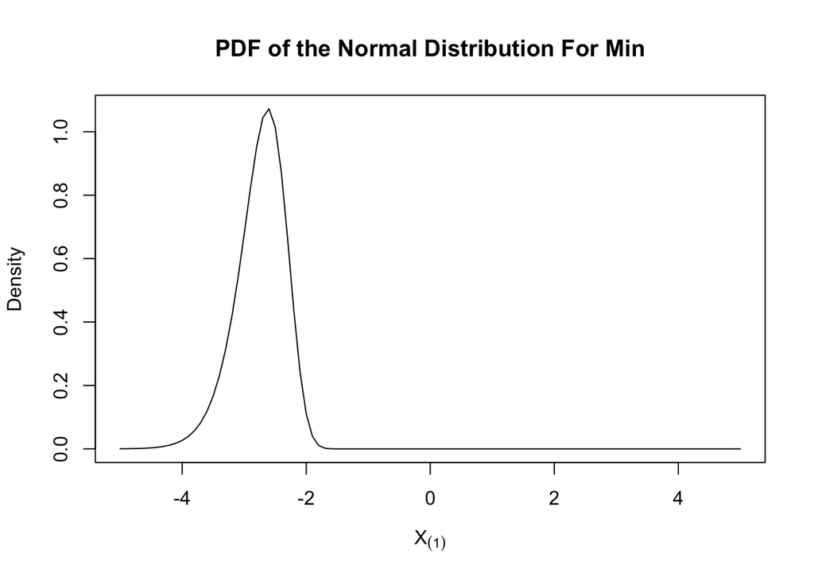

```r
curve(dorder(x, k = 1, dist = "norm"), -5, 5, xlab = parse(text="X[(1)]"), ylab = "Density", main= "PDF of the Normal Distribution For Min")
```

Here, we try to find the probability for sample min. Sample min here is 1. From the plot, we find the min is between -2 and -4. the result is same with density result.

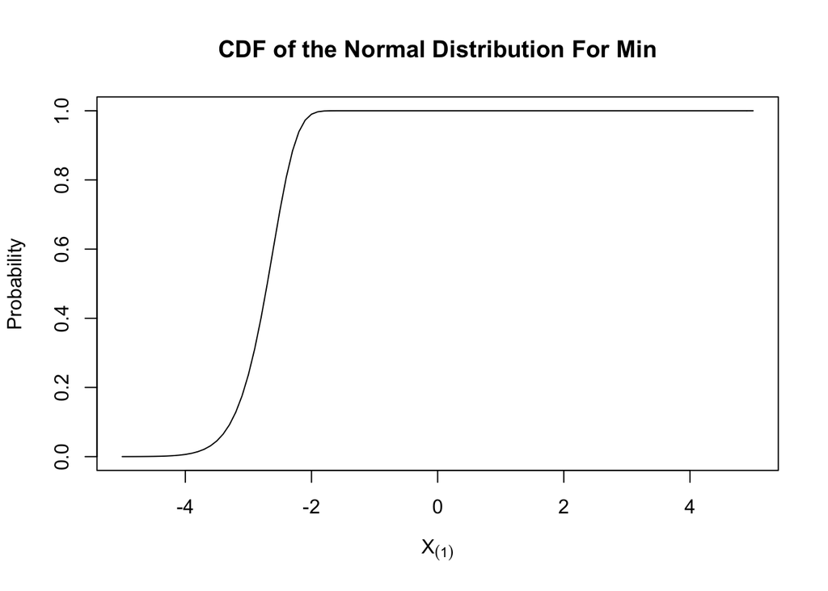

```r
curve(porder(x, k = 1, dist = "norm"), -5, 5, xlab = parse(text="X[(1)]"), ylab = "Probability", main= "CDF of the Normal Distribution For Min")
```